# محاسبه و رسم همبستگی متغیرها

مصورسازی

ggplot2

در این پست با کتابخانه corrr آشنا خواهیم شد که به ما قابلیت های مختلفی برای محاسبه و رسم همبستگی متغیرهای یک دیتافریم می دهد.

mcnakhes mcnakhaee.com  
07-28-2020

### مقدمه

یکی از گام های مهم برای پیاده سازی یک مدل یادگیری ماشین مرحله انتخاب ویژگی (feature selection) است. در این مرحله ما معمولا به دنبال این هستیم که از میان همه ویژگی هایی که در دیتاست موجود هستند تنها مهمترین ویژگی ها (متغیرهایی) که به ما برای پیشبینی متغیر هدف ما کمک می کنند را انتخاب کنیم تا عملکرد مدل مان را بهبود ببخشیم. به علاوه اگر فقط مهمترین ویژگی ها را انتخاب کنیم این مساله به ما کمک می کند تا خروجی مدل مان را به راحتی تفسیر کنیم ( هر چه تعداد متغیرهایی که مدل بر اساس آن پیشبینی انجام می دهد کمتر باشد فهم و درک خروجی مدل برای ما ساده تر می شود). یکی از صلی ترین روش ها برای انتخاب ویژگی محاسبه همبستگی بین ویژگی ها و حذف ویژگی هایی است که با متغیر هدف وابستگی زیادی ندارند یا همبستگی بالایی با بقیه ویژگی ها دارند.

### نصب

کتابخانه corrr بر روی CRAN قرار دارد و برای همین با اجرای دستور زیر می توانیم این کتابخانه را نصب می کنیم.

```r
install.packages("corrr")
```

### استفاده از کتابخانه corrr

```r
library(corrr)
library(tidyverse)
library(dadegan)
```

اصلی ترین تابع کتابخانه corrr تابع correlate است .این تابع یک شی از نوع دیتافریم یا tbl را می گیرد و همبستگی بین متغیرهای را محاسبه می‌کند و آن‌ها را به صورت یک دیتافریم به ما باز می گرداند. در این دیتافریم هر ستون متناظر با یک متغیر و هر سطر نیز متناظر با یک متغیر است. یک دیتافریم از همبستگی ها را به ما باز می گرداند.

```r
corr_df <- spotify %>%
  select(danceability:time_signature)  %>%
  correlate()
head(corr_df)
```

```
# A tibble: 6 x 13
  rowname danceability  energy     key loudness     mode speechiness
  <chr>          <dbl>   <dbl>   <dbl>    <dbl>    <dbl>       <dbl>
1 dancea…      NA       0.621   0.0660   0.439  -0.129       0.262
2 energy        0.621  NA       0.0662   0.762  -0.179       0.311
3 key           0.0660  0.0662 NA        0.0336 -0.0989      0.0655
4 loudne…       0.439   0.762   0.0336  NA      -0.207       0.165
5 mode         -0.129  -0.179  -0.0989  -0.207  NA          -0.00151
6 speech…       0.262   0.311   0.0655   0.165  -0.00151    NA
# … with 6 more variables: acousticness <dbl>,
#   instrumentalness <dbl>, liveness <dbl>, valence <dbl>,
#   tempo <dbl>, time_signature <dbl>
```

به صورت پیشفرض `correlate` همبستگی پیرسون را برای ما محاسبه می‌کند ولی می‌توانیم با آرگومان `method` می‌توانیم از میان سایر روش‌های محاسبه همبستگی مثل `kendall` یا `kendall` استفاده کنیم.

همین طور به صورت پیشفرض مقدار همبستگی یک متغیر با خودش برابر با NA در نظر گرفته می شود. البته می توانیم این رفتار را با پارامتر diagonal تغییر دهیم.

همانطور که گفتم خروجی تابع correlate یک دیتافریم از کلاس tibble است. در این حالت می توانیم این خروجی را به وسیله پایپ لاین به عنوان ورودی به توابع دیگر کتابخانه های tidyverse بدهیم. به طول مثال، می توانیم فقط همبستگی هایی که بالاتر از 0.5 هستند را انتخاب کنیم.

```r
corr_df %>%
  filter(energy >0.5) %>%
  select(danceability,loudness,valence)
```

```
# A tibble: 3 x 3
  danceability loudness valence
         <dbl>    <dbl>   <dbl>
1       NA        0.439   0.609
2        0.439   NA       0.414
3        0.609    0.414  NA
```

علاوه بر تابع `correlate` کتابخانه corrr چندین تابع مفید دیگر را هم در دسترس ما قرار می دهد.یکی از این توابع تابع `shave` است که نیمه بالا یا پائین دیتافریم همبستگی ها را که اساسا تکراری است حذف می کند و به ما نمایش می دهد. تابع `fashion` هم خروجی دیتافریم همبستگی را کمی برای ما زیبا و مرتب می کند.

```r
corr_df %>%
  filter(energy > 0.5) %>%
  shave() %>%
  fashion()
```

```
       rowname danceability energy  key loudness mode speechiness
1 danceability
2     loudness          .44    .76
3      valence          .61    .64  .05
  acousticness instrumentalness liveness valence tempo time_signature
1
2
3
```

تابع focus کتابخانه corrr هم مثل تابع select عمل می کند با این تفاوت که نه تنها با ستون ها را انتخاب می کنیم بلکه می توانیم سطرها را هم انتخاب کنیم.

```r
corr_df %>%
  focus(danceability,loudness,valence,mirror = TRUE)
```

```
# A tibble: 3 x 4
  rowname      danceability loudness valence
  <chr>               <dbl>    <dbl>   <dbl>
1 danceability       NA        0.439   0.609
2 loudness            0.439   NA       0.414
3 valence             0.609    0.414  NA
```

### رسم نمودارهای همبستگی

کتابخانه corrr دو تابع هم برای رسم نمودار همبستگی بین متغیرهای در اختیار ما قرار می دهد. تابع اول `rplot` است که همبستگی بین متغیرها را به صورت دو به دو برای ما رسم می کند.

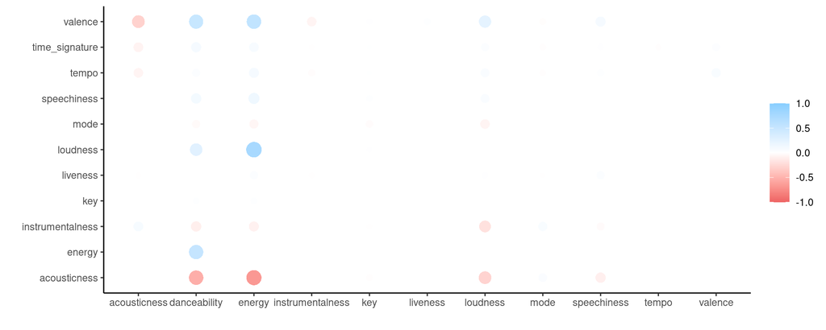

```r
corr_df %>%
  shave %>%
  rplot
```

تابع دیگر `network_plot` است که به نظرم ایده جالبی برای رسم رابطه همبستگی بین متغیرها دارد. این تابع مقدار همبستگی بین متغیرها را به صورت یک گراف (شبکه) برای ما رسم می کند که رنگ هر گراف متناظر با میزان همبستگی بین دو متغیر است.

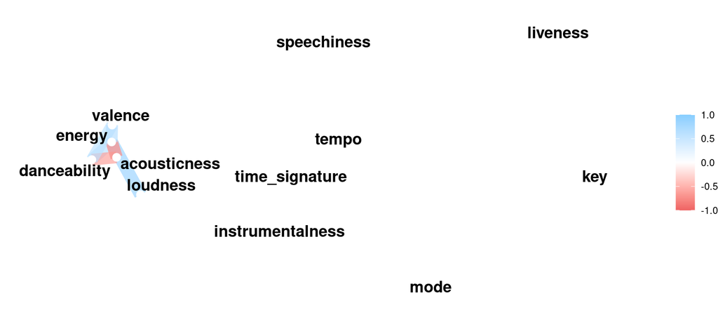

```r
corr_df %>%
  network_plot(min_cor = 0.5,
               curved = FALSE)
```

منبع:

https://cran.r-project.org/web/packages/corrr/vignettes/using-corrr.html